# Homework 4 DATA3421

LeMaur Kydd

2023-03-03

```r
library(plyr)
library(readr)
library(ggplot2)
library(ggcorrplot)
library(dplyr)
library(psych)
```

```r
wine = read.table('winequality.csv', header=TRUE, sep = ',')
glimpse(wine)
```

```
## Rows: 6,497
## Columns: 13
## $ fixed.acidity        <dbl> 7.4, 7.8, 7.8, 11.2, 7.4, 7.4, 7.9, 7.3, 7.8, 7.5…
## $ volatile.acidity     <dbl> 0.700, 0.880, 0.760, 0.280, 0.700, 0.660, 0.600, …
## $ citric.acid          <dbl> 0.00, 0.00, 0.04, 0.56, 0.00, 0.00, 0.06, 0.00, 0…
## $ residual.sugar       <dbl> 1.9, 2.6, 2.3, 1.9, 1.9, 1.8, 1.6, 1.2, 2.0, 6.1,…
## $ chlorides            <dbl> 0.076, 0.098, 0.092, 0.075, 0.076, 0.075, 0.069, …
## $ free.sulfur.dioxide  <dbl> 11, 25, 15, 17, 11, 13, 15, 15, 9, 17, 15, 17, 16…
## $ total.sulfur.dioxide <dbl> 34, 67, 54, 60, 34, 40, 59, 21, 18, 102, 65, 102,…
## $ density              <dbl> 0.9978, 0.9968, 0.9970, 0.9980, 0.9978, 0.9978, 0…
## $ pH                   <dbl> 3.51, 3.20, 3.26, 3.16, 3.51, 3.51, 3.30, 3.39, 3…
## $ sulphates            <dbl> 0.56, 0.68, 0.65, 0.58, 0.56, 0.56, 0.46, 0.47, 0…
## $ alcohol              <dbl> 9.4, 9.8, 9.8, 9.8, 9.4, 9.4, 9.4, 10.0, 9.5, 10.…
## $ quality              <int> 5, 5, 5, 6, 5, 5, 5, 7, 7, 5, 5, 5, 5, 5, 5, 5, 7…
## $ type                 <chr> "red", "red", "red", "red", "red", "red", "red", …
```

## **Data Visualization:** you have to use different data visualization techniques to answer these questions.

#### 1.Is there a relationship between alcohol content and wine quality?

```r
# Checking the correlation coefficient between alcohol content and wine quality.
cor(wine$alcohol, wine$quality)
```

```
## [1] 0.4443185
```

**Explanation:** A correlation coefficient of 0.44 is considered a moderate correlation.

#### 2.How does red wine’s sulfate concentration compare to white wine? A box plot can be created.

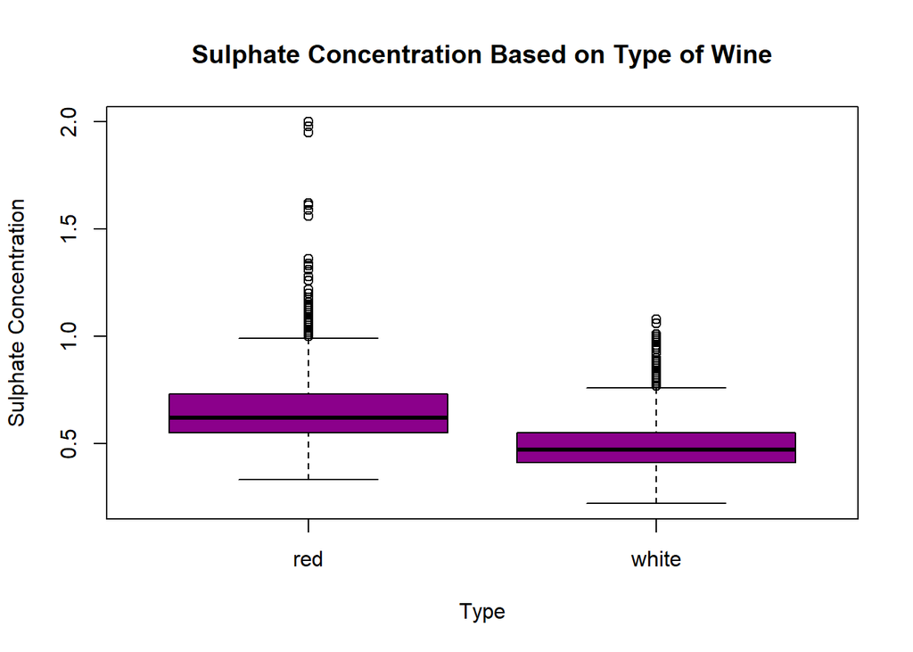

```r
# Creates boxplot showing the spread of sulphate concentration data against the different types of wine
boxplot(sulphates ~ type,
        data = wine,
        xlab='Type',
        ylab='Sulphate Concentration',
        main='Sulphate Concentration Based on Type of Wine',
        col="darkmagenta")
```

#### 3.What is the distribution of wine quality ratings? A histogram or bar plot could be created to visualize the frequency of different quality ratings.

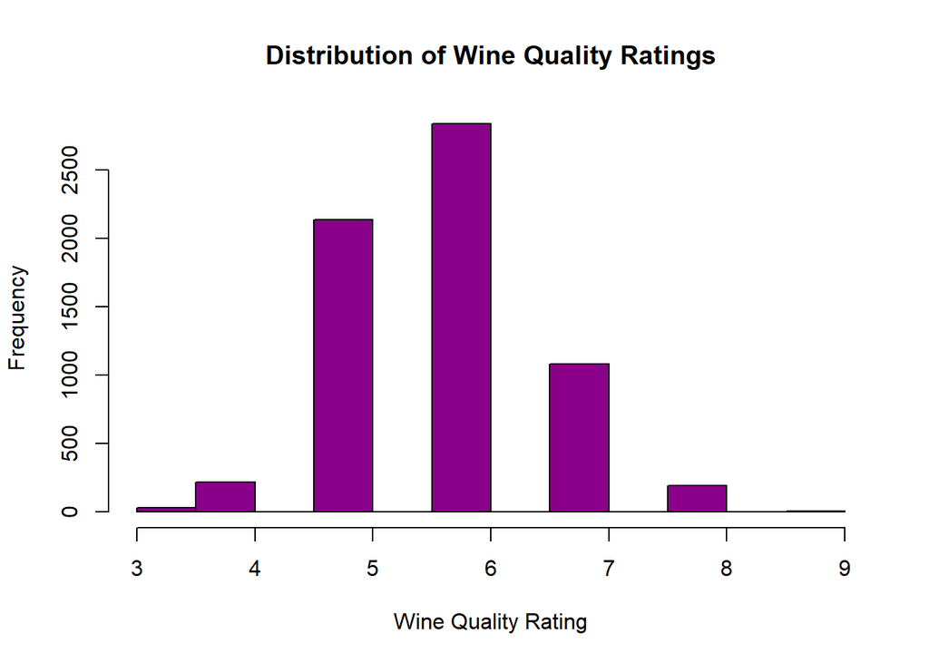

```r
# Creates a histogram illustrating the distribution of wine quality scores
quality = wine$quality
hist(quality, main= 'Distribution of Wine Quality Ratings',
     xlab='Wine Quality Rating',
     col="darkmagenta")
```

#### 4.Are specific chemical properties more strongly associated with higher-quality wines? A correlation or scatter plot matrix could explore the relationships between chemical properties and wine quality ratings.

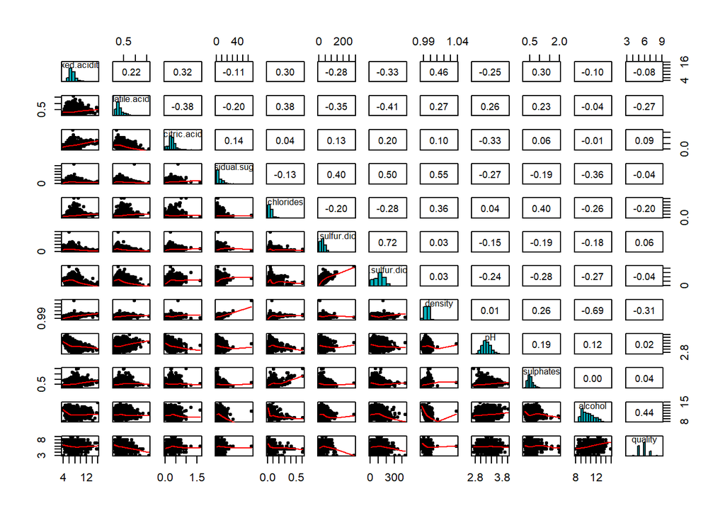

```r
# creates a half correlation matrix half scatter-plot matrix, consisting of all variables in the wine data set except the type variable
pairs.panels(wine[,-13],
             method = "pearson", # correlation method
             hist.col = "#00AFBB",
             density = F,  # show density plots
             ellipses = F # show correlation ellipses
             )
```

**Explanation:** Alcoholic content has the greatest positive correlation of all, 0.44, which is a moderate yet important correlation. The greater the density, chlorides, or volatile.acidity the lower the quality rating, hence the moderate negative correlation.

## **Hypothesis Testing:**

#### 1.Is there a significant difference in alcohol content across different wine quality ratings?

```r
# runs a t-test between the alcoholic content and wine quality score variables
t.test(wine$alcohol, wine$quality)
```

```
##
##  Welch Two Sample t-test
##
## data:  wine$alcohol and wine$quality
## t = 254.83, df = 11906, p-value < 2.2e-16
## alternative hypothesis: true difference in means is not equal to 0
## 95 percent confidence interval:
##  4.637475 4.709371
## sample estimates:
## mean of x mean of y
## 10.491801  5.818378
```

**Explanation:** The p-value of this test is incredibly small and is way smaller than our 0.05 alpha value. This mean we must reject the null hypothesis (there is no significant difference between the variables) and claim that there is a significant difference between the two variables.

#### 2.Is there a significant difference in alcohol content between red wine and white wine?

```r
# runs a chi square test between the alcoholic content and type of wine variables
chisq.test(wine$alcohol, wine$type)
```

```
##
##  Pearson's Chi-squared test
##
## data:  wine$alcohol and wine$type
## X-squared = 330.56, df = 110, p-value < 2.2e-16
```

**Explanation:** The p-value for the chi-square test is very small, smaller than out 0.05 alpha value, meaning there is a significant difference in alcohol content between red wine and white wine.

#### 3.Is there a significant difference in pH levels between high-quality and low-quality wines?

```r
# subsets wine dataset based on high vs. low wine quality ratings
# runs a t-test between the pH levels of high-quality and low-quality wine variables
ph_high = subset(wine,quality %in% c(6,7,8,9))
ph_low = subset(wine,quality %in% c(3,4,5))
t.test(ph_high$pH, ph_low$pH)
```

```
##
##  Welch Two Sample t-test
##
## data:  ph_high$pH and ph_low$pH
## t = 1.5167, df = 4955.6, p-value = 0.1294
## alternative hypothesis: true difference in means is not equal to 0
## 95 percent confidence interval:
##  -0.001839161  0.014409930
## sample estimates:
## mean of x mean of y
##  3.220807  3.214522
```

**Explanation:** The p-value for this test is fairly large, and is above our 0.05 alpha value. This means we fail to reject the null hypothesis and therefore there is no significant difference in the pH’s of these two subsets.